# Projekt z analizy danych

Konrad Kubzdela

25 listopada 2019

# 1 Biblioteki

W projekcie zostały użyte następujące biblioteki

```r
installed.packages()[names(sessionInfo()$otherPkgs), "Version"]
```

```
##       shiny         zoo    corrplot       tidyr   varhandle   heatmaply
##     "1.4.0"     "1.8-6"      "0.84"     "1.0.0"     "2.0.4"     "1.0.0"
##     viridis viridisLite      plotly       caret     lattice      GGally
##     "0.5.1"     "0.3.0"     "4.9.1"    "6.0-84"   "0.20-38"     "1.4.0"
##    reshape2     ggplot2       dplyr       knitr
##     "1.4.3"     "3.2.1"     "0.8.3"      "1.26"
```

# 2 Powtarzalność wyników

Kod zapewniający powtarzalność wyników przy tych samych danych

```r
set.seed(22)
knitr::opts_chunk$set(cache=T)
```

# 3 Wczytanie danych

Wszystkie dane wczytuję jako dane numeryczne. Pomijam pierwszą kolumnę zawierającą numer porządkowy rekordu. Znaki zapytania wczytuję jako NA.

```r
data <- read.table("sledzie.csv",header = TRUE,sep=',',na.strings = "?", colClasses=c("NULL", rep(c("numeric"),15)))
```

# 4 Obłsuga brakujących wartości

Najpierw sprawdzam jaki jest stosunek wierszy z brakującymi wartościami do wszystkich wierszy. Wynosi on ponad 20% dlatego nie będę ich pomijał i brakujące wartości zastąpię średnimi z kolumn.

```r
sum(is.na(data))/nrow(data)
```

```
## [1] 0.2102621
```

```r
data<-na.aggregate(data)
```

# 5 Podsumowanie danych

Dane składają się z ponad 52 tysięcy wierszy. Wyliczam cechy statystyczne atrybutów.

```r
dim(data)
```

```
## [1] 52582    15
```

```r
summary(data)
```

```
##      length         cfin1             cfin2             chel1
##  Min.   :19.0   Min.   : 0.0000   Min.   : 0.0000   Min.   : 0.000
##  1st Qu.:24.0   1st Qu.: 0.0000   1st Qu.: 0.2778   1st Qu.: 2.469
##  Median :25.5   Median : 0.1333   Median : 0.7012   Median : 6.083
##  Mean   :25.3   Mean   : 0.4458   Mean   : 2.0248   Mean   :10.006
##  3rd Qu.:26.5   3rd Qu.: 0.3603   3rd Qu.: 1.9973   3rd Qu.:11.500
##  Max.   :32.5   Max.   :37.6667   Max.   :19.3958   Max.   :75.000
##      chel2            lcop1              lcop2             fbar
##  Min.   : 5.238   Min.   :  0.3074   Min.   : 7.849   Min.   :0.0680
##  1st Qu.:13.589   1st Qu.:  2.5479   1st Qu.:17.808   1st Qu.:0.2270
##  Median :21.435   Median :  7.1229   Median :25.338   Median :0.3320
##  Mean   :21.221   Mean   : 12.8108   Mean   :28.419   Mean   :0.3304
##  3rd Qu.:27.193   3rd Qu.: 21.2315   3rd Qu.:37.232   3rd Qu.:0.4560
##  Max.   :57.706   Max.   :115.5833   Max.   :68.736   Max.   :0.8490
##       recr              cumf             totaln             sst
##  Min.   : 140515   Min.   :0.06833   Min.   : 144137   Min.   :12.77
##  1st Qu.: 360061   1st Qu.:0.14809   1st Qu.: 306068   1st Qu.:13.63
##  Median : 421391   Median :0.23191   Median : 539558   Median :13.86
##  Mean   : 520367   Mean   :0.22981   Mean   : 514973   Mean   :13.87
##  3rd Qu.: 724151   3rd Qu.:0.29803   3rd Qu.: 730351   3rd Qu.:14.16
##  Max.   :1565890   Max.   :0.39801   Max.   :1015595   Max.   :14.73
##       sal            xmonth            nao
##  Min.   :35.40   Min.   : 1.000   Min.   :-4.89000
##  1st Qu.:35.51   1st Qu.: 5.000   1st Qu.:-1.89000
##  Median :35.51   Median : 8.000   Median : 0.20000
##  Mean   :35.51   Mean   : 7.258   Mean   :-0.09236
##  3rd Qu.:35.52   3rd Qu.: 9.000   3rd Qu.: 1.63000
##  Max.   :35.61   Max.   :12.000   Max.   : 5.08000
```

# 6 Rozkłąd atrybutów

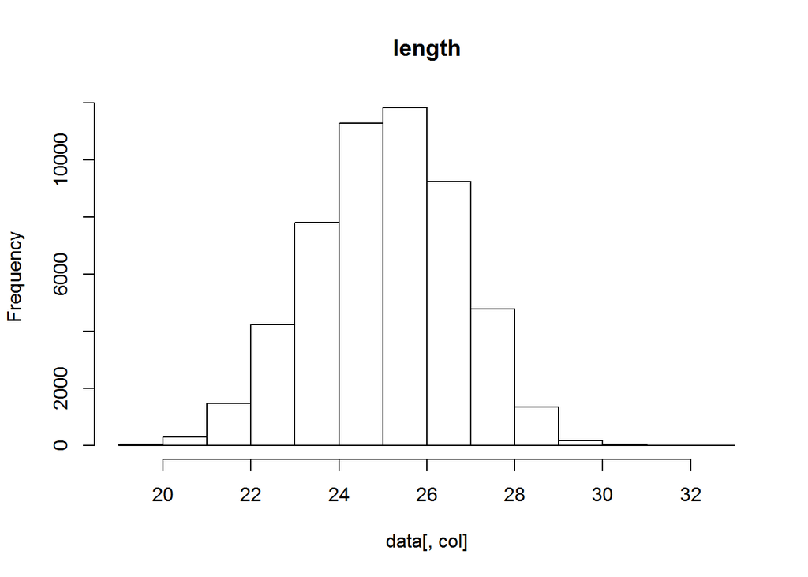

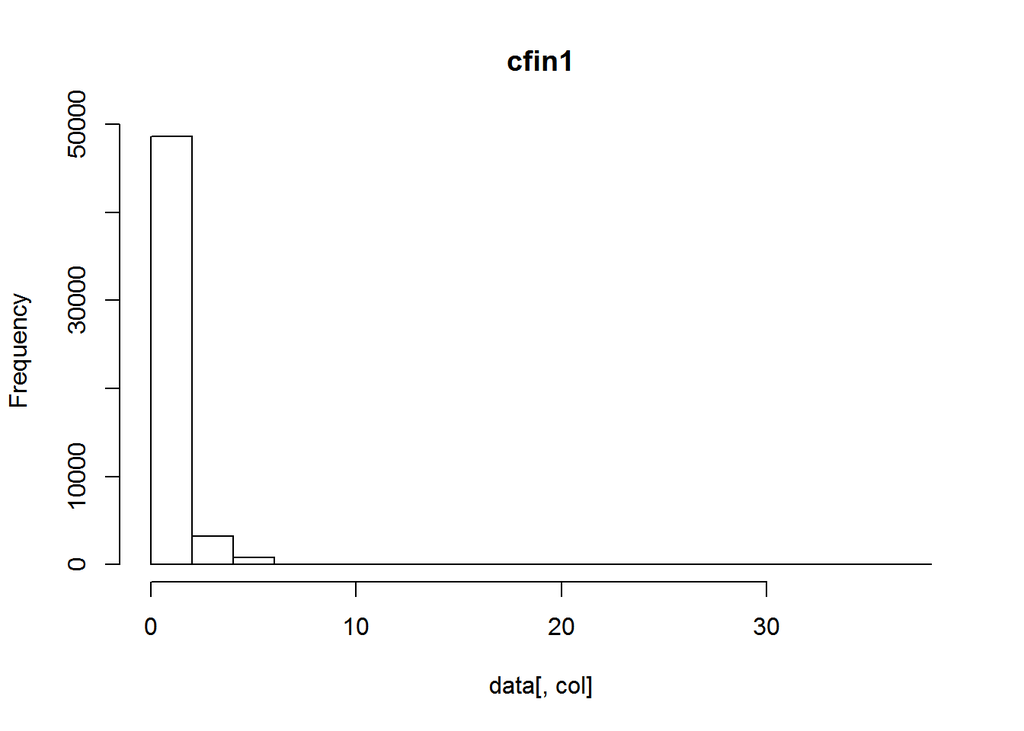

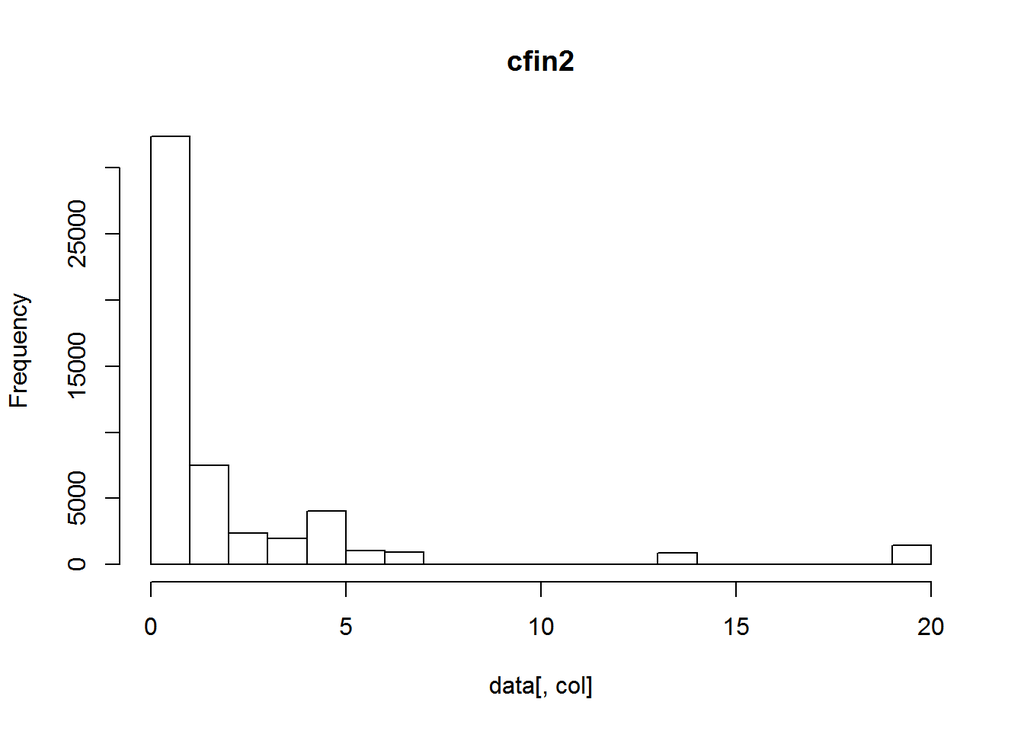

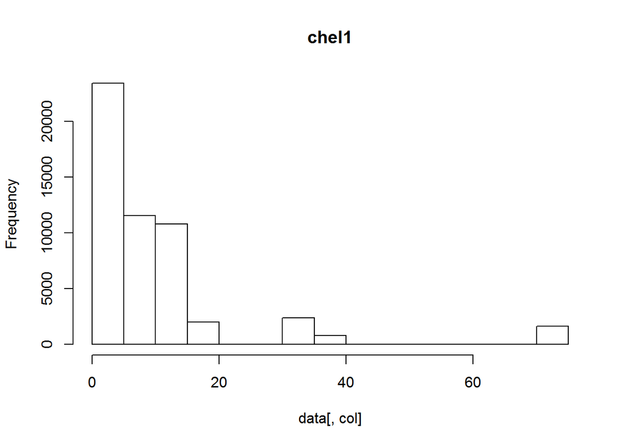

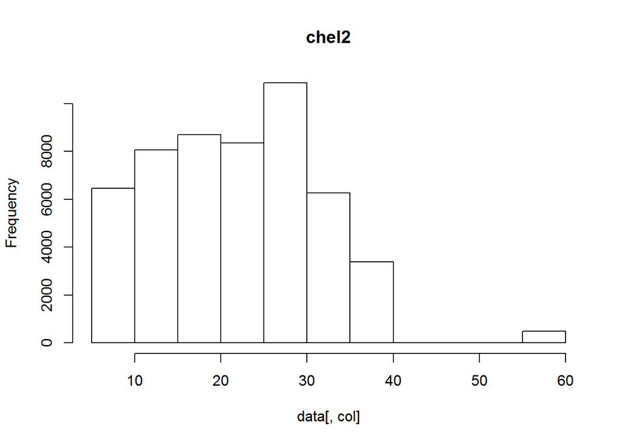

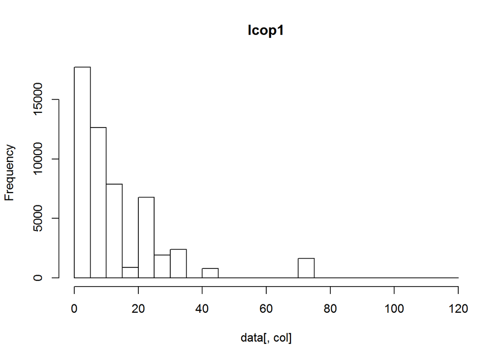

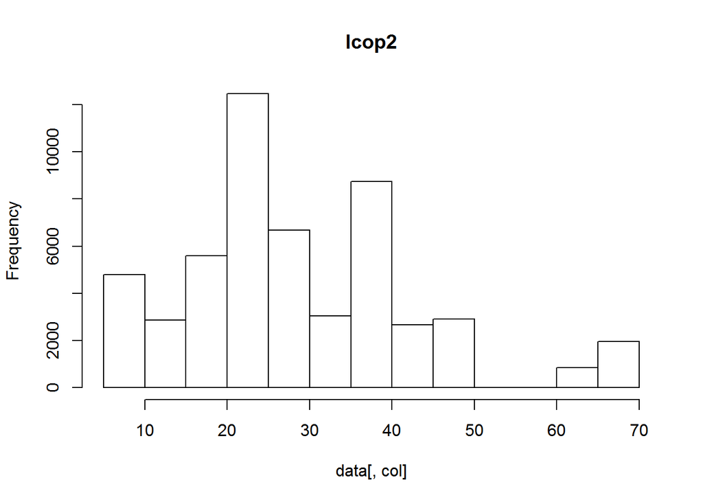

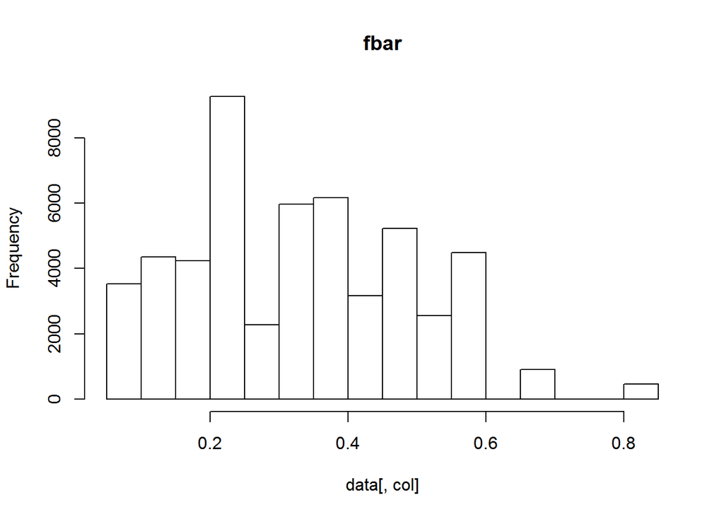

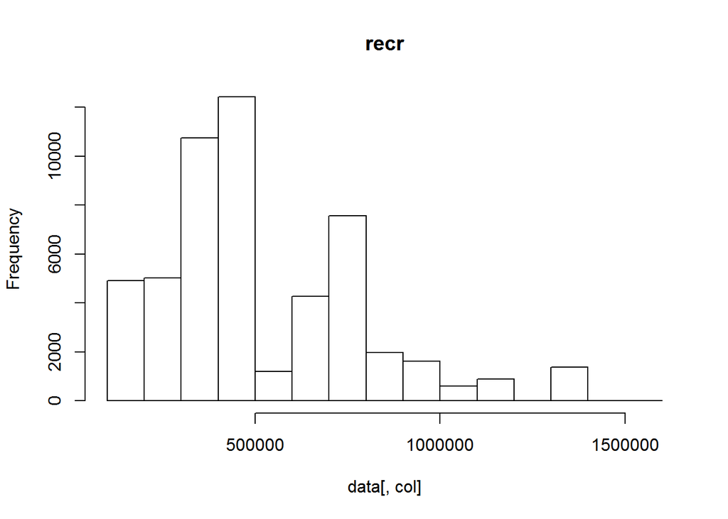

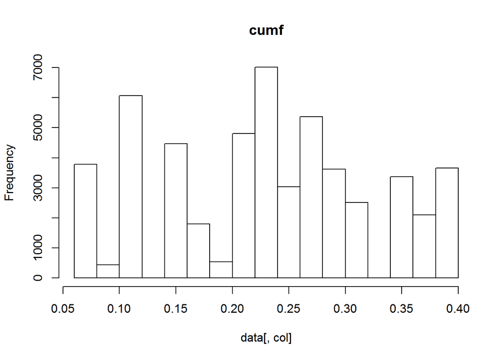

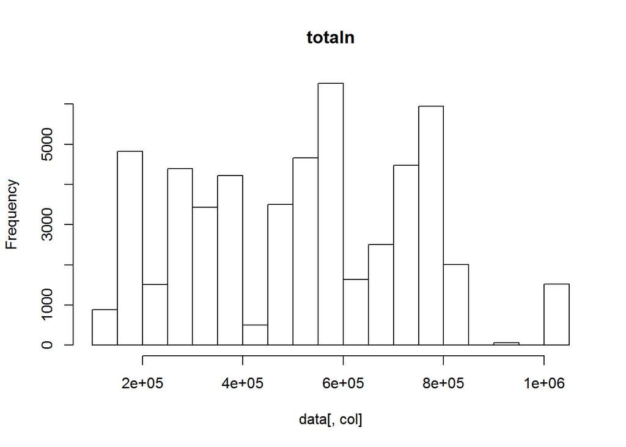

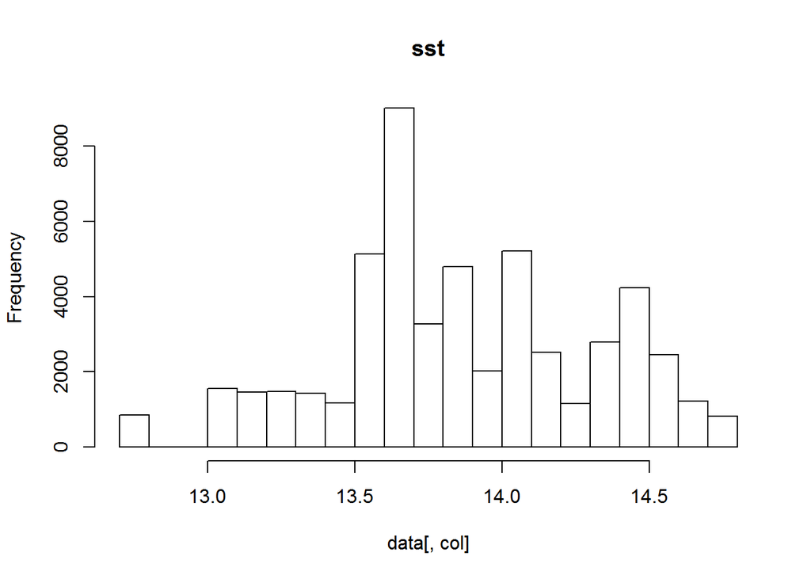

[3 more figures not shown]

```r
for (col in 1:ncol(data)) {
   hist(data[,col],main = names(data[col]))
}
```